# Miniproject_2

TRAILERs Can Tell:

Correlating Movie Success with Movie Trailers

Packages Included

```python
import requests
import bs4
import json
import time
import matplotlib.pyplot as plt
import seaborn as sns
import sqlite3
import numpy as np
import re
import pandas as pd
proxies={
    'http':'http://206.189.157.23',
    'https': 'http://206.189.157.23'}
%matplotlib inline
```

EXECUTIVE SUMMARY

With the rise of technology, one of the most affected business sectors is the Movie Industry. The Movie Industry has been always a lucrative business. With the right Marketing and Sales Strategy, every movie production will be a box office hit. Due to this, the Movie Industry has been doing a lot of reformations in its Marketing Steps and one this are the heavy use of movie trailers for each of their movie production.

Nowadays, movie trailers can be seen left and right, and especially in video sharing platforms like YouTube. Movie studios use the surge of YouTube users to freely market their movie. With the use of movie trailers, they can attract and entice viewers who were able to see the movie trailers on YouTube. With this strategy, a lot of users of YouTube will be looking forward to the movie. In This paper, we will be tackling the correlation of movie trailers on the movie success on Three Success Factors, namely: Movie Awards, Movie Ratings, and Movie Earnings.

To discuss such correlation, Top 100 Movies Titles from 2020 until 2010 was web scraped from Rotten Tomatoes website. Rotten Tomatoes is one of the leading movie critic rating platforms on the web as of present which makes it a viable source of information. Using the generated movie titles, additional information from IMDb (another leading movie database) was extracted using web scraping. Such information includes movie profits, movie rating, movie awards and nominations and the likes. Using also the Movie Title, Movie Trailer Information was extracted in YouTube Website using web scraping and YouTube API. Such Information includes view counts, likes and dislikes count and many more. Using all the extracted data, the paper was able to conclude significant findings.

INTRODUCTION

As of 2020, the movie industry has a $33 Billion US Market Size [1]. This proves that the movie Iindustry is lucrative business venture. During its growth, the movie industry has implemented different marketing strategies to produce significant gross profit through the year. With the rise of technology and internet, the movie industry is expanding its areas of marketing. As of present. With heavy usage of the internet nowadays, the movie industry has been using a lot of video sharing platforms to market and entice viewers to watch their produced movie. One of these marketing strategies is to make movie trailers out of the movies and upload to video platforms like YouTube. Movie Trailers are about 2 minute videos that contains snippets of scenes from the Movie. Movie trailers, in a sense, acts a video summary depicting a general genre and plot of the movie. Due to this, a surge of movie trailer can be seen left and right in YouTube. Can Movie trailers affect a Movie Success? Its Movie Ratings? Earnings? Awards?

**Rotten Tomatoes**

Rotten Tomatoes (RT) is one of the leading movies and TV series review website at present day. It was initially founded and made back in 1998. Currently Rotten Tomatoes Domains has a monthly unique visitor amounting to 26 Million globally. This means that it is heavily used by a lot of users for different purposes. RT has different movie rating features. The process is that RT first collect online reviews from certified members of various guild and films critic associations and calculates the percentage of positive reviews. To be a Certified to be a Rotten Tomatoes Critics, there are certain protocols that are needed to be addressed and passed first. Some of its unique movie rating features are the Tomatometer Ranking wherein movies are tagged as either Certified Fresh, Fresh or Rotten, depending on their rating. There is an Audience score rating where it calculates the percentage of registered users who rated the film positively on a 5–star scale[2]. Within Rotten Tomatoes, there are a lot of different groupings of ratings, and for this paper, we will be using Rotten Tomatoes Top 100 Movie Per year, from 2010 to 2020. Figure 1 Shows the top page of Top Movies Section of RT.

*Figure 1. Sample Rotten Tomatoes Page*

[figure not shown]

**IMDB**

Like Rotten Tomatoes, IMDb is one of the leading online movie rating websites. IMDb (Internet Movie Database) houses a lot of information pertaining to not only movie ratings and movie critics/reviews but also film trivia, production crew name and personal biographies. Its database has more information on the specific movie title comparing to rotten tomatoes. As of Present, IMDb Database has almost 6.5 Million Titles from movies to tv series episodes and a lot more. For this Paper, we will be cross-referencing information from the Top 100 Movies Titles from Rotten Tomatoes from IMDb Database to find additional information.[3] Figure 2 show a sample movie from IMDB.

*Figure 2 Sample IMDb Page*

[figure not shown]

**YouTube and Movie Trailers**

YouTube is an online video sharing platform owned by Google. It hosts billions of different videos by billions of different users. A lot of movie companies utilize youtube to freely extend their movie's marketing across youtube's userbase through movie trailers. These movie trailers contain snippets of the movie itself to make viewers excited for the upcoming showing. Movie trailers on the YouTube have different information like number of views, likes and dislikes. Within this paper, we would like to find the correlation of the movie trailer information on how it can bring success to the movie.

PROBLEM STATEMENT

### *Can Youtube movie trailer statistics be indicative of Movie success in terms of earnings, ratings and awards?*

BUSINESS VALUE

- **Cinemas**: These correlations can be used for forecasting demand based on official trailer performance. Cinemas can optimize the scheduling of the movies to maximize profit.
- **Producers**: Forecast revenues based on its trailer performance
- **Marketing**: Give insights on how to best market movies

METHODOLOGY

To properly address the problem, the researchers will be needing viable data on regarding Movie Informations and their corresponding Movie Trailers. Note that there are a wide array of selection for possible collection of data but one of the most interesting point of reference are the informations on the different website. There are currently two Top Movie Rating sites (Rotten Tomatoes and IMDB) as of date. Also the corresponding Movie Trailers can be found in Youtube Website which is one of the top most video sharing platform. The Researchers will follow the general workflow defined below to arrive at a conclusion and recommendation.

*Figure 3: A general workflow of the study*

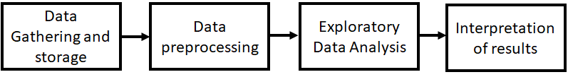

### OVERVIEW OF THE METHODOLOGY

Each step will be discussed in detail in the following sections. To give a general overview of the methodology, a brief description for each step is described below:

#### 1. Data Gathering

- *Rotten Tomatoes webscraping*: Website scraping of the top 100 movies per year listed for the last 10 years (2020 to 2010) from the top Movie Rating.
- *IMDB API and webscraping:* Movie titles retrieved from rotten tomatoes were then used to obtain complementary information from IMDB. The OMDB API was used to gather relevant information. The imdb ids from the API were then used to retrieve more movie information and was done via webscraping.
- *Youtube API* Using the scraped Movie Names, data on its respective official movie trailers, uploaded on **YouTube** were gathered via the YouTube API.
- The data gathered for each website is stored separately in an sql database.

#### 2. Data Preprocessing:

- The gathered data was cleaned and formatted prior analysis. The steps involved are:
  - Removing duplicates
  - Converting movie titles to lower case
  - Converting numbers represented as strings to integer/float
  - Standardizing the format/naming convention for the 3 database.

The three database were then merged for analysis. and engineered variables are introduced.

#### 3. Exploratory Data Analysis

- The processed data was analyzed by obtaining basic statiscal measures, and finding the correlation of the Scraped Movie Informations and the Youtube VIdeo Trailer Informations.

#### 4. Interpretation of Results

- Analyzed the findings on EDA.

DATA GATHERING

### Rotten Tomatoes Webscraping:

In Rotten Tomatoes, there is a section where they list all the top 100 Movies for that year according to the ratings that is stored on their website. They have a ton list ranging from different years. For limitations of research, we will be looking only the year from **2010 to 2020**.

The Website scraping process is started from the initial page of Top 100 Movies of the Year 2020, characterized by the link: https://www.rottentomatoes.com/top/bestofrt/?year=2020

1. First We will be making a simple SQL Database file and make a connection to it for us to store the information.
2. The Program below will use the library **import request** to get the html code string text and then will be parsed by the beautiful soup library function. A Simple Iteration from the Year 2020 to 2010 and just changing the Year string on the link: *https://www.rottentomatoes.com/top/bestofrt/?year=*. We can get all the URL list for the home page listing of the top 100 Movies. Which will be then used for latter processing.

*Figure 4. Show a Sample Top 100 Movie Page of Rotten Tomatoes vs its HTML Code*

[figure not shown]

The suceeding program will at least run for 3 hours

```python
conn = sqlite3.connect('sample.db')

conn.execute("""
    CREATE TABLE IF NOT EXISTS mytable (
        Year TEXT ,
        Position INTEGER ,
        Title TEXT ,
        Tomatometer_Score TEXT ,
        Total_Count TEXT ,
        Audience_Score TEXT ,
        Verfied_Ratings TEXT ,
        Rating TEXT ,
        Genre TEXT ,
        Directed_by TEXT ,
        Written_by TEXT ,
        In_Theaters TEXT ,
        On_Disc_Streaming TEXT ,
        Box_Office Text,
        Runtime TEXT,
        Studio TEXT )""")
conn.commit()

conn = sqlite3.connect('sample.db')

top = 'https://www.rottentomatoes.com/top/bestofrt/?year='
yeartop = 2020
toplink = []
while (yeartop != 2009):
    newlink = top+str(yeartop)
    yeartop = yeartop - 1
    toplink.append(newlink)
```

1. On the Initial page of the Top 100 for every year, we can get the URL link of each Movie Title characterized by the "itemListElement" attribute which can brought by the json.loads program. We can then collect the all 100 URLs for that year.
1. Using simple for loop system again from the URL list of the top 100, we can now again request the html code for each movie, this time, we will know be on the main page of the movie where all the information is stored. Using a try and error analogy and beautiful soup loading, we can use regex expression on the strings to find the necessary information we need. Upon finding it will be then appended to a list. In the event of not having a match, it will append the none string which mean, the movie doesn't have that information.
1. All Information will be then stored in the database file. The program below will run the above-mentioned processes.

*Figure 5. Show a Sample Specific Movie Page on RT vs its HTML Code*

[figure not shown]

**NOTE** Running the code will at least take **3 hours** to finish since a time sleep program was added to safe web scraping. Also, proxy vpn are used also in case of any untoward events.

```python
for a in toplink:
    wp = bs4.BeautifulSoup(requests.get(a, proxies=proxies).text)
    file = json.loads(wp.find_all('script')[1].string)
    x2 = 0
    list1 = []
    for x in file['itemListElement']:
        list1.append(x['url'])

    year = int(file['mainEntityOfPage'].replace('Top 100 Movies of ', ''))

    for x1 in list1:
        try:
            wp1 = bs4.BeautifulSoup(requests.get(x1, proxies=proxies).text)

            list2 = []
            list2.append(year)
            x2 = x2 + 1
            list2.append(x2)
            list2.append(wp1.title.text.replace(' - Rotten Tomatoes', ''))

            z = ''
            for x in wp1.find_all(name='div', class_="mop-ratings-wrap__half"):
                z1 = (x.text.strip().replace('\n', '').replace(
                    '  ', '').replace('\xa0', ' '))
                z = z+z1+'&&&'

            list2.append(''.join(re.findall(r'(.*?)TOMATOMETER', z)))
            list2.append(''.join(re.findall(r'Total Count: (.+?)&&&', z)))
            list2.append(''.join(re.findall(r'&&&(.+?)Audience', z)))
            list2.append(''.join(re.findall(r'Ratings: (.+?)&&&', z)))

            y = ''
            for x in wp1.find_all(name='li', class_="meta-row clearfix"):
                y1 = (x.text.strip().replace('\n', '').replace(
                    '  ', '').replace('\xa0', ' '))
                y = y+y1+'&&&'

            list2.append(''.join(re.findall(r'Rating:(.+?)&&&', y)))
            list2.append(''.join(re.findall(r'Genre:(.+?)&&&', y)))
            list2.append(''.join(re.findall(r'Directed By:(.+?)&&&', y)))
            list2.append(''.join(re.findall(r'Written By:(.+?)&&&', y)))
            list2.append(''.join(re.findall(r'In Theaters:(.+?)&&&', y)))
            list2.append(''.join(re.findall(r'On Disc/Streaming:(.+?)&&&', y)))
            list2.append(''.join(re.findall(r'Box Office:(.+?)&&&', y)))
            list2.append(''.join(re.findall(r'Runtime:(.+?)&&&', y)))
            list2.append(''.join(re.findall(r'Studio:(.+?)&&&', y)))

            with conn:
                conn.execute(
                    """INSERT INTO mytable VALUES (?, ?, ?, ?, ?,
                    ?, ?, ?, ?, ?, ?, ?, ?, ?,?, ?)""", list2)

            time.sleep(2)

        except:
            print(list2)
```